# project3

Keon Park_01700005, Seungchan Oh_01603277, Dayoung Han_01903952

2021 5 24

## R Markdown

```r
data_enzyme <- read.table("enzyme.txt", header=TRUE)
attach(data_enzyme)
```

## 1. Perform a parameter estimation for each of the candidate models.

Three different models are used

1. Competitive inhibition

$v = \frac{V_{max}[S]}{K_{M}(1 + \frac{[I]}{K_{Ic}}) + [S]}$

- $V_{max}$ = thetas[1]
- $K_{M}$ = thetas[2]
- $K_{Ic}$ = thetas[3]
2. Uncompetitive inhibition

$v = \frac{V_{max}[S]}{K_{M} + [S](1 + \frac{[I]}{K_{Iu}})}$

- $V_{max}$ = thetas[1]
- $K_{M}$ = thetas[2]
- $K_{Iu}$ = thetas[3]
3. Mixed inhibition

$v = \frac{V_{max}[S]}{K_{M}(1 + \frac{[I]}{K_{Ic}}) + [S](1 + \frac{[I]}{K_{Iu}})}$

- $V_{max}$ = thetas[1]
- $K_{M}$ = thetas[2]
- $K_{Ic}$ = thetas[3]
- $K_{Iu}$ = thetas[4]

Below are functions of each model

```r
# Competitive inhibition model.
# thetas[1]: Vmax, thetas[2]: KM, thetas[3]: KIC
competitive <- function(sdata, idata, thetas) {
  v <- thetas[1] * sdata/(thetas[2]*(1+idata/thetas[3]) + sdata)
  return(v)
}
# Uncompetitive inhibition model.
# thetas[1]: Vmax, thetas[2]: KM, thetas[3]: KIC
uncompetitive <- function(sdata, idata, thetas) {
  v <- thetas[1]*sdata/(thetas[2] + sdata*(1+idata/thetas[3]))
  return(v)
}
# Mixed inhibition model
# thetas[1]: Vmax, thetas[2]: KM, thetas[3]: KIC, thetas[4]: KIu
mixed <- function(sdata, idata, thetas) {
  v <- thetas[1]*sdata/(thetas[2]*(1+idata/thetas[3]) + sdata*(1+idata/thetas[4]))
  return(v)
}
```

The residual sum of squares as objective function is below.

v_est used “do.call” function which construct and executes a function from a function and a list of arguments.

```r
Jobjective <- function(thetas, FUN, sdata, idata, vdata) {
  v_est <- do.call(FUN, list(sdata, idata, thetas))
  v_resid <- vdata - v_est
  J <- sum(v_resid^2)
  return(J)
}
```

## 2. Optimizing the parameter values by using objective function

Good starting values of parameters for dataset are:

- $V_{max} = 0.2$
- $K_{M} = 0.5$
- $K_{Ic} = 300$
- $K_{Iu} = 100$

```r
# Initial parameter values for each model.
compar <- c(0.2, 0.5, 300)
uncompar <- c(0.2, 0.5, 100)
mixpar <- c(0.2, 0.5, 300, 100)

# Optimizing the parameter values by using objective function.
competitivefit <- optim(par = compar, fn = Jobjective, FUN = competitive, sdata = conc, idata = inhibitor, vdata = rate)
uncompetitivefit <- optim(par = uncompar, fn = Jobjective, FUN = uncompetitive, sdata = conc, idata = inhibitor, vdata = rate)
mixedfit <- optim(par = mixpar, fn = Jobjective, FUN = mixed, sdata = conc, idata = inhibitor, vdata = rate)

# Optimal estimated parameter values of Competitive inhibition model.
competitivefit$par
```

```
## [1]   0.2044001   0.2289033 223.4785210
```

```r
# Optimal estimated parameter values of Uncompetitive inhibition model.
uncompetitivefit$par
```

```
## [1]   0.2434434   0.4966576 983.1678841
```

```r
#Optimal estimated parameter values of Mixed inhibition model.
mixedfit$par
```

```
## [1]    0.2148457    0.2722400  301.5835127 4536.0074224
```

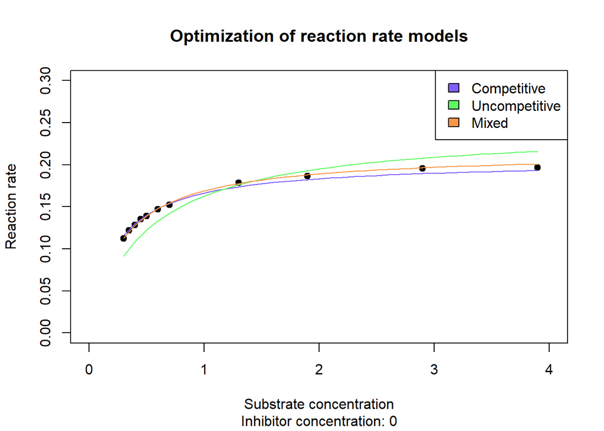

```r
color <-  c('#805FFA', '#5DFA61', '#FA9643')
xseq <- seq(min(conc), max(conc), 0.1)

plot(x = conc[inhibitor==0], y = rate[inhibitor==0], main = "Optimization of reaction rate models", xlim = c(0, 4), ylim = c(0, 0.3), ylab = "Reaction rate", xlab = "Substrate concentration", sub='Inhibitor concentration: 0', pch = 19)
lines(x=xseq, y=competitive(xseq, 0, competitivefit$par), col = color[1])
lines(x=xseq, y=uncompetitive(xseq, 0, uncompetitivefit$par), col = color[2])
lines(x=xseq, y=mixed(xseq, 0, mixedfit$par), col = color[3])
legend(x = "topright", legend = c("Competitive", "Uncompetitive", "Mixed"), fill = color)
```

Reaction rate graph, when inhibitor concentration is 0.

‘Mixed’ seems to fit closer to observations than other models.

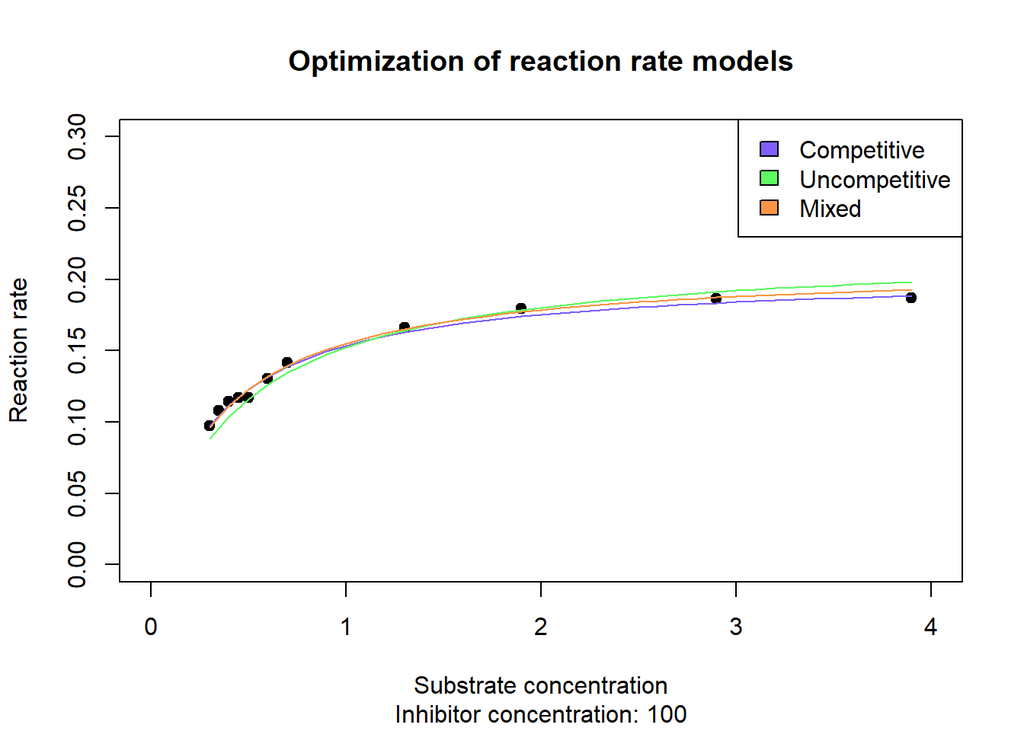

```r
plot(x = conc[inhibitor==100], y = rate[inhibitor==100], main = "Optimization of reaction rate models", xlim = c(0, 4), ylim = c(0, 0.3), ylab = "Reaction rate", xlab = "Substrate concentration", sub='Inhibitor concentration: 100', pch = 19)
lines(x=xseq, y=competitive(xseq, 100, competitivefit$par), col = color[1])
lines(x=xseq, y=uncompetitive(xseq, 100, uncompetitivefit$par), col = color[2])
lines(x=xseq, y=mixed(xseq, 100, mixedfit$par), col = color[3])
legend(x = "topright", legend = c("Competitive", "Uncompetitive", "Mixed"), fill = color)
```

Reaction rate graph, when inhibitor concentration is 100.

It is difficult to determine which model is more fit to observations visually.

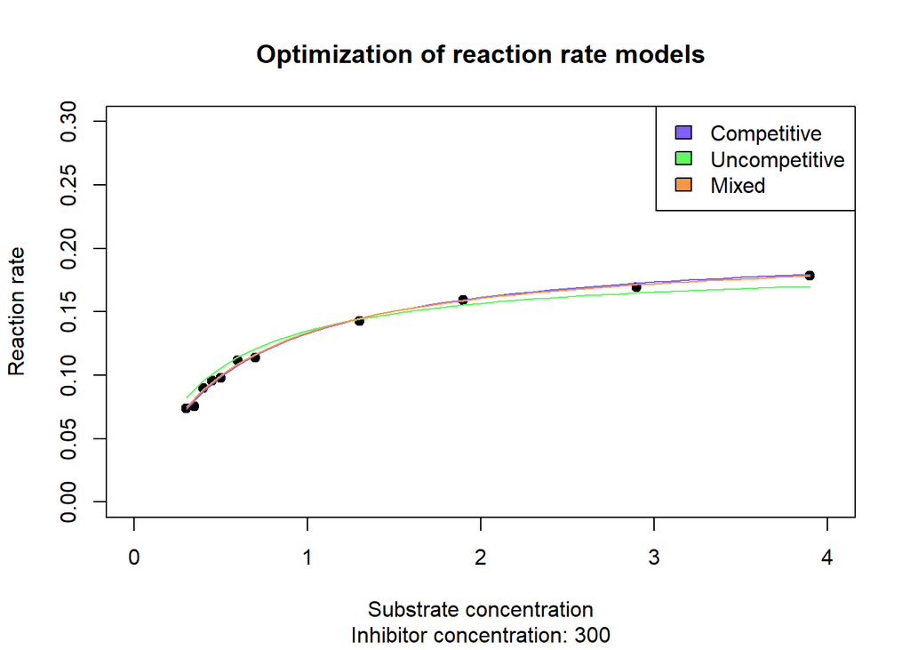

```r
plot(x = conc[inhibitor==300], y = rate[inhibitor==300], main = "Optimization of reaction rate models", xlim = c(0, 4), ylim = c(0, 0.3), ylab = "Reaction rate", xlab = "Substrate concentration", sub='Inhibitor concentration: 300', pch = 19)
lines(x=xseq, y=competitive(xseq, 300, competitivefit$par),  col = color[1])
lines(x=xseq, y=uncompetitive(xseq, 300, uncompetitivefit$par), col = color[2])
lines(x=xseq, y=mixed(xseq, 300, mixedfit$par), col = color[3])
legend(x = "topright", legend = c("Competitive", "Uncompetitive", "Mixed"), fill = color)
```

Reaction rate graph, when inhibitor concentration is 300.

It seems competitive and mixed models are closer to observations than uncompetitive model.

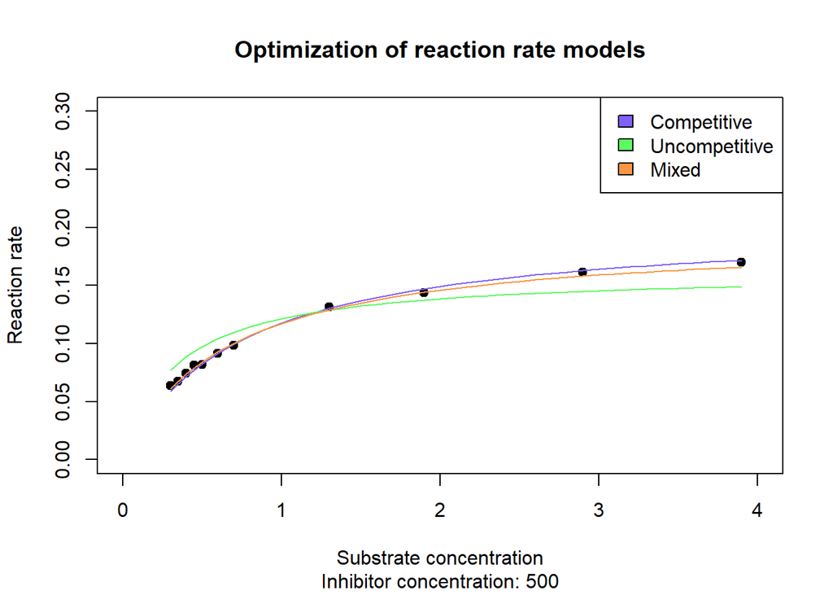

```r
plot(x = conc[inhibitor==500], y = rate[inhibitor==500], main = "Optimization of reaction rate models", xlim = c(0, 4), ylim = c(0, 0.3), ylab = "Reaction rate", xlab = "Substrate concentration", sub='Inhibitor concentration: 500', pch = 19)
lines(x=xseq, y=competitive(xseq, 500, competitivefit$par),  col = color[1])
lines(x=xseq, y=uncompetitive(xseq, 500, uncompetitivefit$par), col = color[2])
lines(x=xseq, y=mixed(xseq, 500, mixedfit$par), col = color[3])
legend(x = "topright", legend = c("Competitive", "Uncompetitive", "Mixed"), fill = color)
```

Reaction rate graph, when inhibitor concentration is 500.

It seems competitive and mixed models are closer to observations than uncompetitive model.

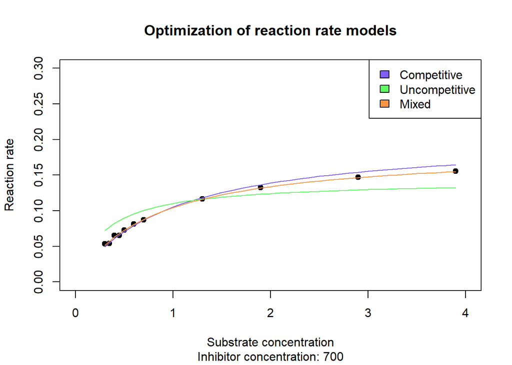

```r
plot(x = conc[inhibitor==700], y = rate[inhibitor==700], main = "Optimization of reaction rate models", xlim = c(0, 4), ylim = c(0, 0.3), ylab = "Reaction rate", xlab = "Substrate concentration", sub='Inhibitor concentration: 700', pch = 19)
lines(x=xseq, y=competitive(xseq, 700, competitivefit$par), col = color[1])
lines(x=xseq, y=uncompetitive(xseq, 700, uncompetitivefit$par), col = color[2])
lines(x=xseq, y=mixed(xseq, 700, mixedfit$par), col = color[3])
legend(x = "topright", legend = c("Competitive", "Uncompetitive", "Mixed"), fill = color)
```

It seems mixed line is fit to dots than others.

We plot five different graphs that shows rate of reaction based on each inhibitor concentration: 0, 100, 300, 500, 700.

Especially uncompetitive inhibition model does not match to observations.

When it comes to competitive and mixed models, it is difficult to compare visually which model is better.

Therefore, we verify through AIC and F-test to select the best model.

## 3. Select the best model on the basis of both the Akaike Information Criterion (AIC) and F- test.

```r
# Akaike Information Criterion (AIC) function is coded below.
AIC <- function(thetas, FUN, sdata, idata, vdata) { #s i v
  RSS <- Jobjective (thetas, FUN, sdata, idata, vdata)
  N <- length(sdata)
  p <- length(thetas)
  A <- N*log(RSS/N) + 2 * p # Akaike's: 2p, Bayesian: plog(N)
  return(A)
}

# Calculated AIV values for each model.
AIC(competitivefit$par, competitive, conc, inhibitor, rate)
```

```
## [1] -626.3995
```

```r
AIC(uncompetitivefit$par, uncompetitive, conc, inhibitor, rate)
```

```
## [1] -471.786
```

```r
AIC(mixedfit$par, mixed, conc, inhibitor, rate)
```

```
## [1] -659.7099
```

# Perform Akaike Information Criterion

In order to pick the best model, perform Akaike Information Criterion which is an estimator of prediction error.

Since AIC estimates the quality of each model, and relative to each of the other models such that it provides a means for model selection.

AIC is the score for the model. Lower AIC value indicates a better fit-model and a model with a delta-AIC (the difference between the two AIC values being compared) of more than -2 is considered significantly better model that the model being compared to.

- The Lowest Value for Competitive Inhibition Model: -626.3995
- The Lowest Value for Uncompetitive Inhibition Model: -471.786
- The Lowest Value for Mixed Inhibition Model: -659.7099

If we don’t consider F-test, than Mixed inhibition model is the best model.

In order to confirm that Mixed inhibition model is the best model, F-test is performed below.

```r
Ftest <- function(thetas1, thetas2, FUN1, FUN2, sdata, idata, vdata) {
  RSS1 <- Jobjective(thetas1, FUN1, sdata, idata, vdata)
  RSS2 <- Jobjective(thetas2, FUN2, sdata, idata, vdata)
  N <- length(sdata)
  p1 <- length(thetas1)
  p2 <- length(thetas2)
  F <- ((RSS1 - RSS2) / (p2 - p1)) / (RSS2 / (N - p2))
  pvalue <- pf(F, df1 = p2 - p1, df2 = N - p2, lower.tail = FALSE)
  return(list(F = F, df1 = abs(p2 - p1), df2 = N - p2, pValue = pvalue))
}
# F-test between Competitive inhibition model and Mixed inhibition model.
Ftest(competitivefit$par, mixedfit$par, competitive, mixed, conc, inhibitor, rate)
```

```
## $F
## [1] 45.91473
##
## $df1
## [1] 1
##
## $df2
## [1] 51
##
## $pValue
## [1] 1.229309e-08
```

```r
# F-test between Uncompetitive inhibition model and Mixed inhibition model.
Ftest(uncompetitivefit$par, mixedfit$par, uncompetitive, mixed, conc, inhibitor, rate)
```

```
## $F
## [1] 1560.606
##
## $df1
## [1] 1
##
## $df2
## [1] 51
##
## $pValue
## [1] 6.46665e-40
```

## Perform F-test

F-test indicates whether linear regression model provides a better fit to the data than a model that contains no independent variables.

The F-value is a ratio of two quantities that are expected to be roughly equal under the null hypothesis, which produces a F-value of 1.

A high F-value means that reject the null hypothesis that the group means are equal. Also, p-value of F-test gives us significance level.

If the p-value is less than the significance level (0.05), sample data provide sufficient evidence to conclude that regression model fits the data better than the model with no independent variables.

**F-test between Competitive inhibition model and Mixed inhibition model.**

$H_{0}$: The prediction of mixed inhibition model is not significantly improved than the one of competitive inhibition model.

$H_{A}$: The prediction of mixed inhibition model is significantly improved than one of competitive inhibition model.

- Critical F-value: 4.03
- F-value: 45.91473

$H_{0}$ is rejected so that $H_{A}$ is selected: mixed inhibition model is significantly improved than one of competitive inhibition model.

**F-test between Uncompetitive inhibition model and Mixed inhibition model.**

$H_{0}$: The prediction of mixed inhibition model is not significantly improved than the one of uncompetitive inhibition model.

$H_{A}$: The prediction of mixed inhibition model is significantly improved than one of uncompetitive inhibition model.

- Critical F-value: 4.03
- F-value: 1560.606

$H_{0}$ is rejected so that $H_{A}$ is selected: mixed inhibitor model is significantly improved than one of uncompetitive inhibition model.

#### **conclusion**

> Based on result of AIC and F-test, Mixed inhibition is selected.

## 4.Perform a sensitivity analysis on each of the parameters of selected model.

```r
# Relativity sensitivity function is defined below.
relativeSensitivity <- function(FUN, sdata, idata, thetas, eps = 1e-5) {
    S <- expand.grid(substrate = sdata, inhibitor = idata, parameter = 1:length(thetas))
    S <- data.frame(S, sensitivity = rep(NA, length(sdata)*length(idata)*length(thetas)))
  for (p in 1:length(thetas)){
    thetas. <- thetas
      thetas.[p] <- thetas[p] * (1 + eps)
      yhat <- do.call(FUN, list(S$substrate[S$parameter==p], S$inhibitor[S$parameter==p], thetas))
    yhat. <- do.call(FUN, list(S$substrate[S$parameter==p], S$inhibitor[S$parameter==p], thetas.))
    S$sensitivity[S$parameter==p] <- ((yhat. - yhat) / (eps*thetas[p])) * abs(thetas[p])
  }
    return(S)
}

sub <- conc[inhibitor==0]
inh <- inhibitor[conc==0.30]

sseq <- seq(min(conc), max(conc), length.out=50)
iseq <- seq(min(inhibitor), max(inhibitor), length.out=50)

df1 <- relativeSensitivity(mixed, sub, inh, mixedfit$par, eps = 1e-5)
df2 <- relativeSensitivity(mixed, sseq, iseq, mixedfit$par, eps = 1e-5)
```

```r
require(ggplot2)
contour_list = list()
parnames = c("V_max","K_M", "K_Ic", "K_Iu")
for (p in 1:length(mixedfit$par)){
  dfp1 <- df1[df1$parameter==p,]
  dfp2 <- df2[df2$parameter==p,]
  gg <- ggplot(data=dfp2, mapping = aes(substrate, inhibitor, z=sensitivity, colour=..level..)) +
  geom_contour(binwidth=0.01)+
  geom_point(data=dfp1, mapping =  aes(x=substrate, y=inhibitor, colour=sensitivity)) +
  labs(title = "Sensitivity Analysis", subtitle = parnames[p]) +
  scale_colour_gradientn(colors=c("#FF1201", "#FAFF0D", "#1256B3"), limit=range(c(min(df1$sensitivity), max(df1$sensitivity))))

  contour_list[[p]] <- gg
}
```

Purpose of sensitivity analysis is to see effect of each parameters has on the outcomes as substrate concentration changes.

In Mixed inhibition model, there are 4 parameters: “$V_{max}$”,“$K_{M}$”, “$K_{Ic}$”, “$K_{Iu}$” and above graphs are for each parameters.

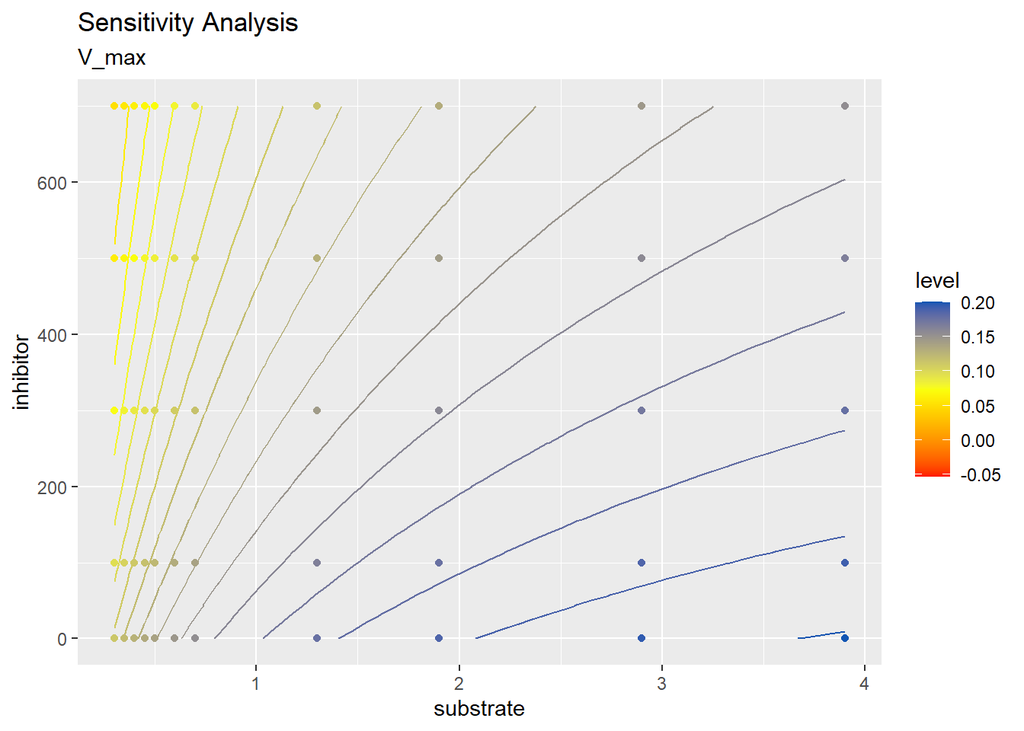

```r
print(contour_list[[1]])
```

Parameter $V_{max}$: It has highest effect when high substrate and low inhibitor. However, as substrate increases and inhibitor decreases, the sensitivity become stronger. When substrate = 3.8, inhibitor = 0, the highest sensitivity is 0.2 approximately.

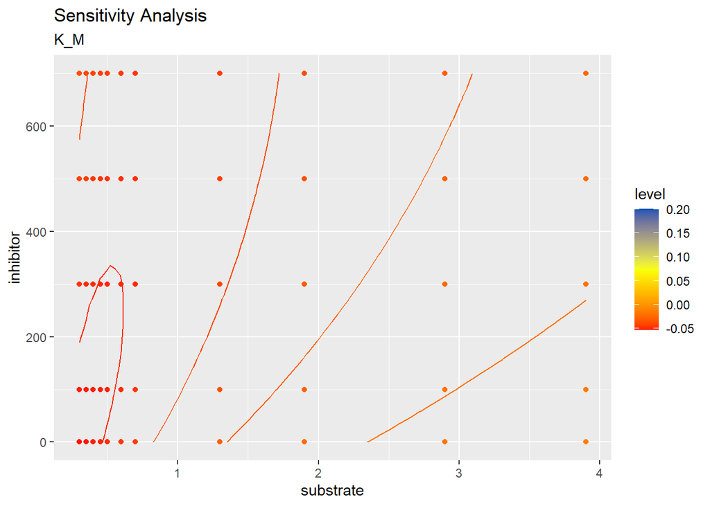

```r
print(contour_list[[2]])
```

Parameter $K_{M}$: Sensitivity increases as substrate increase and inhibitor decrease. When substrate = 3.8, inhibitor = 0, the highest sensitivity is 0 approximately.

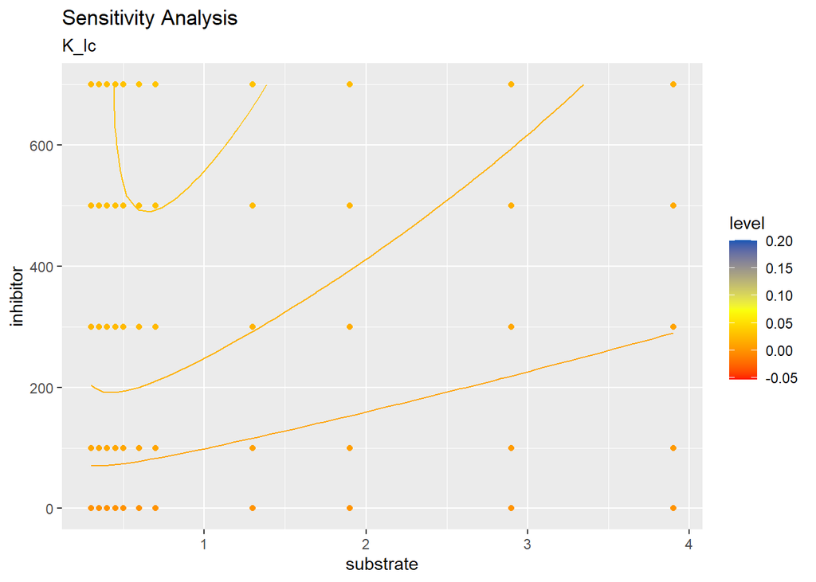

```r
print(contour_list[[3]])
```

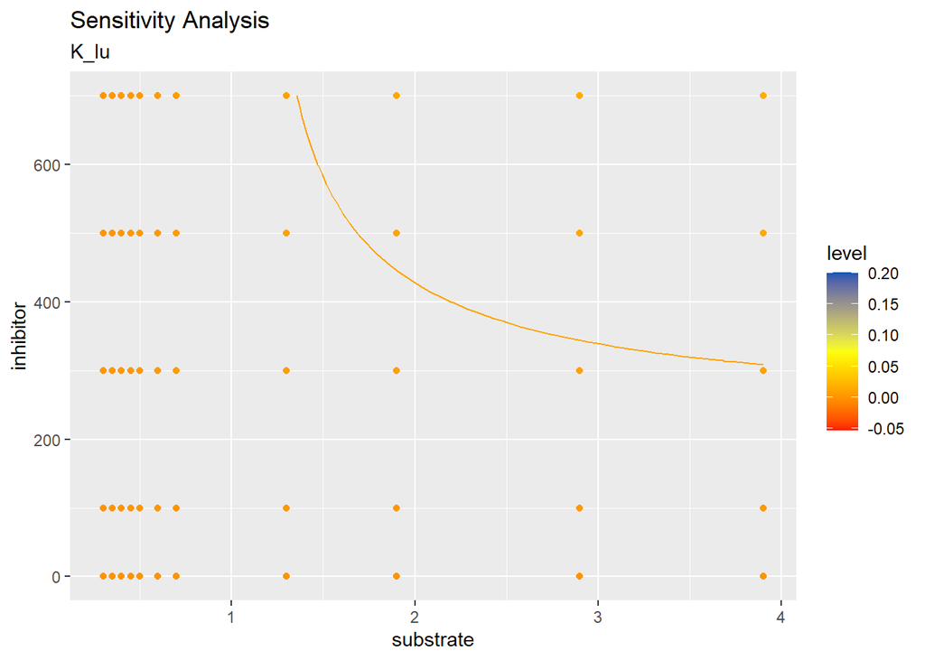

```r
print(contour_list[[4]])
```

Parameter $K_{Iu}$: Sensitivity increases as substrate increase and inhibitor increase. When substrate = 3.8, inhibitor = 700, the highest sensitivity is 0 approximately.

## If you where to repeat the experiment, in which range of input values would you take more measurements?

Based on Sensitivity Analysis graph, we can find the parameter $V_{max}$ has the biggest influence on model.

## 5. Calculate 95% confidence intervals for the parameter estimates of the selected model.

```r
sensitivity <- function(FUN, sdata, idata, thetas, eps = 1e-5) {
    yhat <- do.call(FUN, list(sdata, idata, thetas))
    S <- matrix(NA, nrow = length(sdata), ncol = length(thetas))
    for (p in 1:length(thetas)) {
        thetas. <- thetas
        thetas.[p] <- thetas[p] * (1+eps)
        yhat. <- do.call(FUN, list(sdata, idata, thetas.))
        S[, p] <- (yhat. - yhat) / (eps*thetas[p])
        }
    return(S)
}
# Funtion that calculate Fisher information Matrix.
FisherInformation <- function(FUN, sdata, idata, thetas, eps = 1e-5) {
  sens <- sensitivity(FUN, sdata, idata, thetas, eps)
  FIM <- t(sens)%*%sens
  return(FIM)
}

# Function that calculate 95% confidence interval for the parameter estimates of the model.
confInterval <- function(FUN, sdata, idata, thetas, alpha = 0.05, eps = 1e-5) {
  FIM <- FisherInformation(FUN, sdata, idata, thetas, eps)
  C <- solve(FIM)
  StDev <- sqrt(diag(C))
  N <- length(sdata)
  p <- length(thetas)
  t.05 <- qt(p = 1-alpha/2, df = N-p)

  CI <- data.frame(lower.CI = thetas - StDev * t.05, upper.CI = thetas + StDev * t.05)



  return(CI)
}
# Calculation of Fisher information Matrix.
FIM <- FisherInformation(FUN = mixed, sdata = conc, idata = inhibitor, thetas = mixedfit$par)

# Calculation of 95% confidence interval.
confInterval(FUN = mixed, sdata = conc, idata = inhibitor, thetas = mixedfit$par)
```

```
##        lower.CI     upper.CI
## 1 -1.039379e+00 1.469070e+00
## 2 -5.946165e+00 6.490645e+00
## 3 -1.093934e+04 1.154251e+04
## 4 -4.154392e+05 4.245113e+05
```

Above table is 95% confidence interval of the 4 parameters: “$V_{max}$”,“$K_{M}$”, “$K_{Ic}$”, “$K_{Iu}$”

- Parameter “$V_{max}$” 0.2148455±1.254225 [-1.039379, 1.469070]
- Parameter “$K_{M}$” 0.27224±6.218405 [-5.946165, 6.490645]
- Parameter “$K_{Ic}$” 301.585±11240.92 [-1.093934e+04, 1.154251e+04]
- Parameter “$K_{Iu}$” 4536.05±419975.2 [-4.154392e+05, 4.245113e+05]